# SAGE II: Phages/CRISPR

Vincent Somerville/de Bakker

20/03/2020

## Introduction

Bacteriophages are the top predators in the bacterial world. They infect and thereby shape the diversity of the micorbial community. This is comparable to the introduction of top predators such as wolfes and bares in the Yosemite national park.

Phages not only infect bacteria but they can also have a different functions on their host hosts. For example they can effect the course of the bacterial infection . In fact, based onevolutionary reasoning, prophages are postulated to con-tribute genes that increase the fitness of lysogenic bacteriain their specific ecological niche

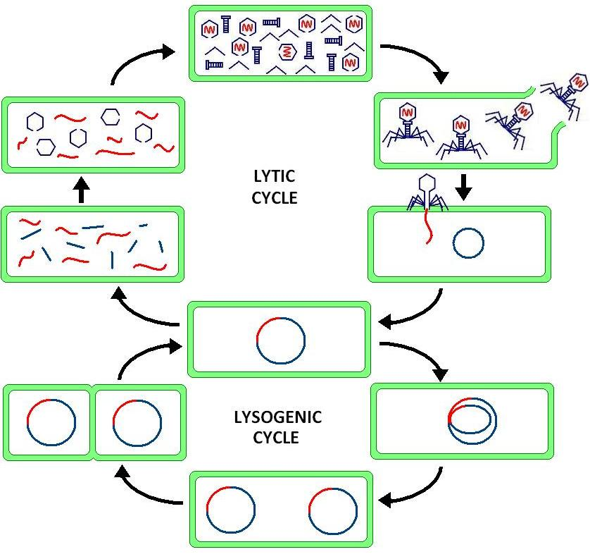

The two main life cyles of phages. source Wikipedia

Phage taxonomy is not very simple, because phages evolve very quickly and the diversity is tremendously large. It is hard to find commonalities to compare the phages. Therefore phages are originally identified based on the phage lytic functions and particle structure. On the other hand people try to infer molecular phylogenic trees from the few common genes. The Institute that organises the naming of phages is the [International Committee on the Taxonomy of Viruses](https://talk.ictvonline.org/).

Here, we look at the diversity Phages in the assembled Bifido bacteria from social Bees. We have two main areas we are focusing on: 1. The Prophages within the assembled Bifido bacteria 2. The CRISPRs (bacterial immunsystem) of the Bifido bacteria

We first start of by looking for prophages within the Bifido bacteria. Prophages are phages that have inserted into the bacterial genomes and piggyback for a while. From time to time they replicate and lyse the bacterial cell by bursting.

## Prophage detection

Here we use the online version of [Phaster](https://phaster.ca/)

## Bifido diveristy on NCBI

Here, I explore and download the Bifido diversity on NCBI RefSeq. NCBI Refseq are currated and selecte high quality genome assemblies.